# HW7

Owen R. Page

March 7, 2018

2. Making a function to create random normal data for il-13 and il-33 cq values based on the following parameters: n=50 for both. N as 50 as this should definitely serve as an effective sample size. The mean of IL 13 is 30.4 and sd is 1.6 as these would serve as good representative values from similar data which I have seen. The same logic went for IL 33.
3. Now generating data based on these values in the form of a normal distribution.

```r
library(ggplot2)
dataCreate <- function(mean2= 22.2, mean1=30.4, n1=50, n2=50, sd1=1.6, sd2=2.2){
  mydf <- data.frame(il13=rnorm(mean=mean1, n=n1, sd=sd1), il33= rnorm(mean=mean2, n=n2, sd=sd2))
  return(mydf)
}

myDF1 <- dataCreate()
head(myDF1)
```

```
##       il13     il33
## 1 30.08852 20.86349
## 2 28.00477 17.17161
## 3 31.19023 23.77461
## 4 31.94163 23.97516
## 5 29.59983 21.81747
## 6 30.31555 20.24972
```

```r
# melt(myDF1) places it in a format that can be used to perform an anova
```

4. Making a function to analyze the random data using a linear regression to determine if a relationship between the two continuous variables is present:

```r
myReg <- function(data=myDF1){
  lreg<- lm(il13~il33, data=data)
  return(lreg)

}
lregr1 <- myReg()
```

4. Making a graph to visualize the data:

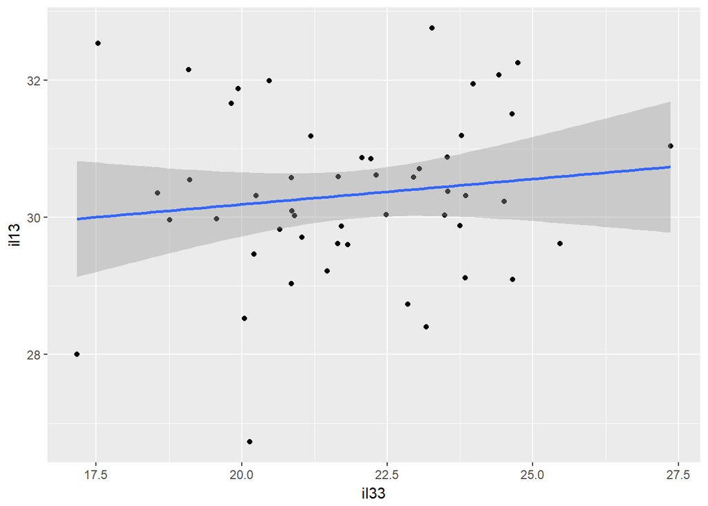

```r
myGraph <- function(data=lregr1){
  regPlot <- ggplot( data=data, mapping=aes(x=il33, y=il13))+
    geom_point()+
    stat_smooth(method=lm)

  return(regPlot)
}
plot1 <-myGraph()
plot1
```

Results of linear regression model:

```r
print(summary(lregr1)$coefficients)
```

```
##                Estimate Std. Error    t value     Pr(>|t|)
## (Intercept) 28.70513171 1.78626530 16.0699151 6.007669e-21
## il33         0.07414207 0.08116616  0.9134603 3.655661e-01
```

Notice that the y intercept seems to be significant yet the slope of IL-33 in relationship to IL-13 seems to be non-significant.

5. Now let’s run this multiple times without changing the parameters:

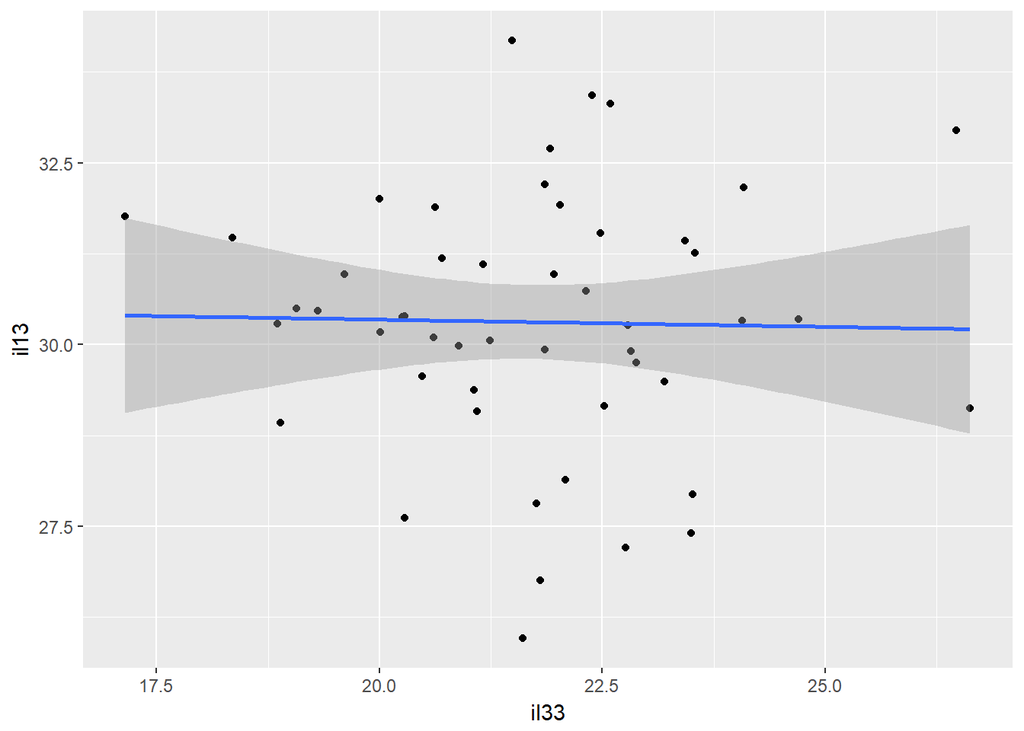

```r
myDF1 <- dataCreate()
lregr1 <- myReg()
plot1 <-myGraph()
plot1
```

```r
print(summary(lregr1)$coefficients)
```

```
##                Estimate Std. Error    t value     Pr(>|t|)
## (Intercept) 30.74328761  2.9490507 10.4248079 6.374147e-14
## il33        -0.01983394  0.1354015 -0.1464825 8.841540e-01
```

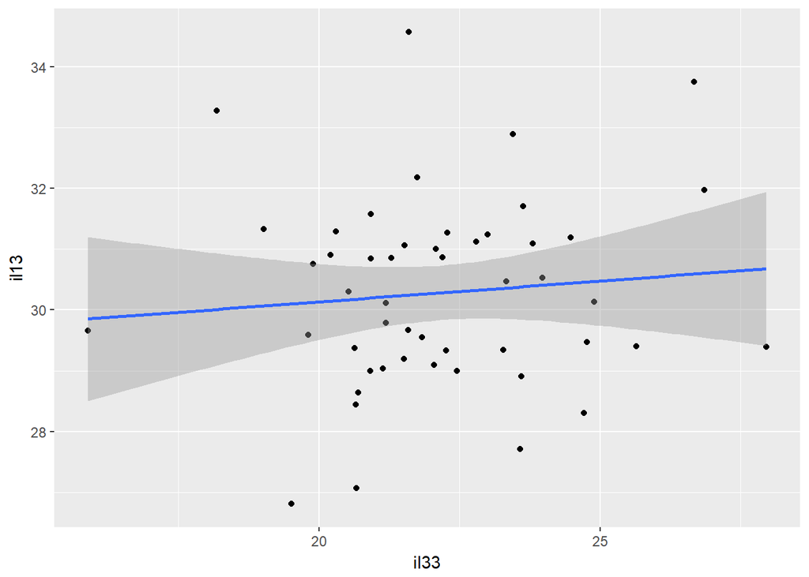

```r
myDF1 <- dataCreate()
lregr1 <- myReg()
plot1 <-myGraph()
plot1
```

```r
print(summary(lregr1)$coefficients)
```

```
##                Estimate Std. Error    t value     Pr(>|t|)
## (Intercept) 28.76241387  2.2482368 12.7933205 4.429998e-17
## il33         0.06850563  0.1010273  0.6780901 5.009705e-01
```

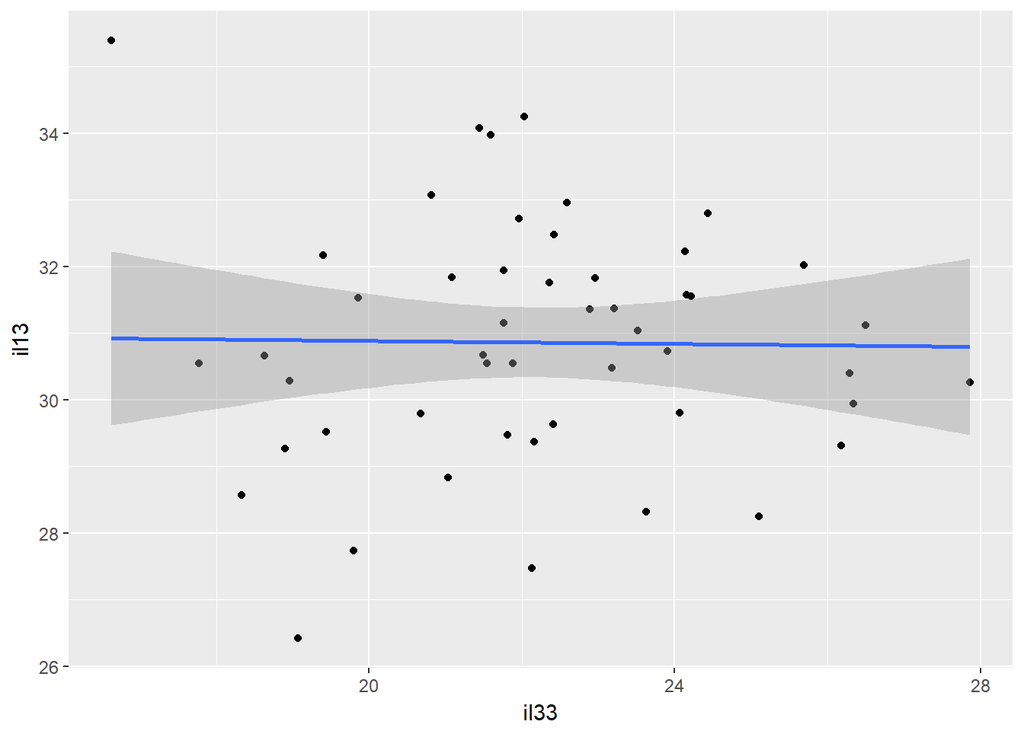

```r
myDF1 <- dataCreate()
lregr1 <- myReg()
plot1 <-myGraph()
plot1
```

```r
print(summary(lregr1)$coefficients)
```

```
##                Estimate Std. Error   t value    Pr(>|t|)
## (Intercept) 31.10342185  2.3861064 13.035220 2.19517e-17
## il33        -0.01107998  0.1068393 -0.103707 9.17834e-01
```

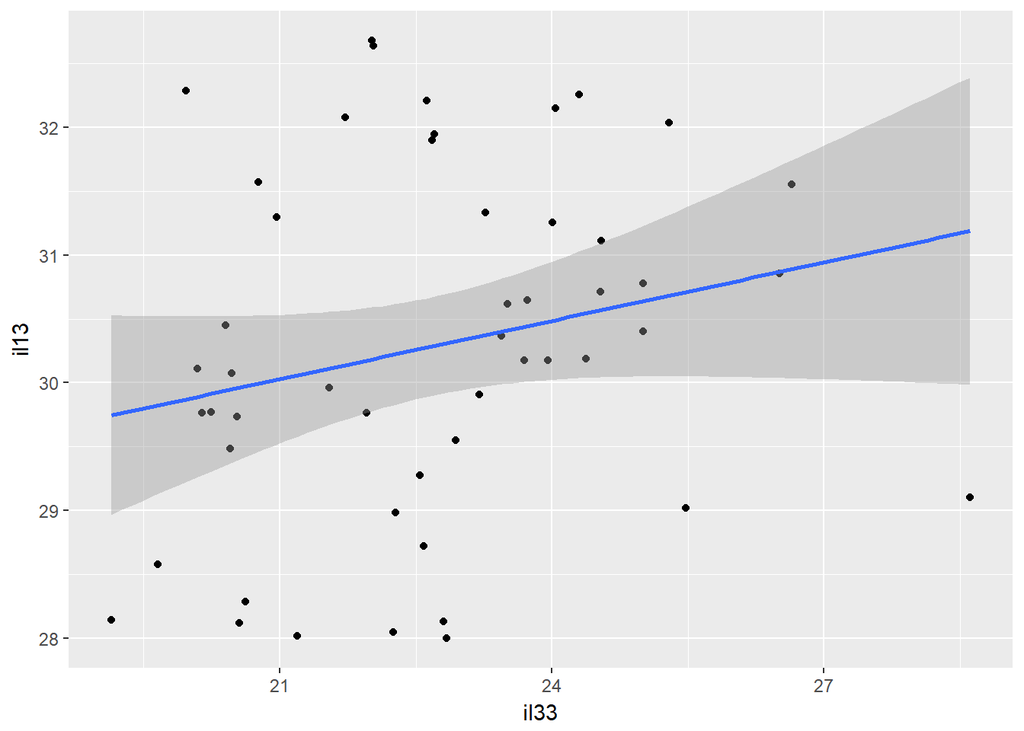

```r
myDF1 <- dataCreate()
lregr1 <- myReg()
plot1 <-myGraph()
plot1
```

```r
orimod<-print(summary(lregr1)$coefficients)
```

```
##               Estimate Std. Error   t value     Pr(>|t|)
## (Intercept) 26.8297597 2.17367876 12.343020 1.669832e-16
## il33         0.1523328 0.09547517  1.595523 1.171593e-01
```

As you can see from the results, some of the slopes calculated by the regression model are positive, some are negative, and overall the non-zero slope is not statistically significant. To me at least, this makes sense as we generated two normal distributions that were never set to be related to one another in any way (so therefore it makes sense that the relationship is random).

6. Now let’s try and tweak our parameters around to see if we can generate a significant slope.

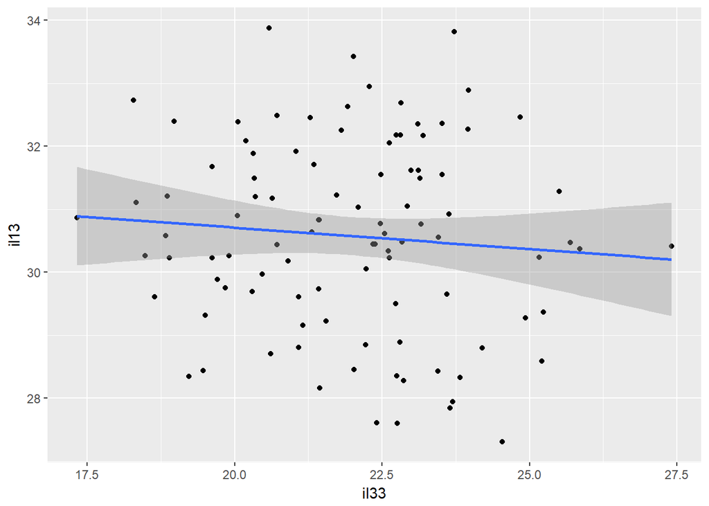

```r
myDF2 <- dataCreate(n1=100, n2=100)
lregr2 <- myReg(data=myDF2)
plot2 <-myGraph(data=lregr2)
plot2
```

```r
print(summary(lregr2)$coefficients)
```

```
##                Estimate Std. Error    t value     Pr(>|t|)
## (Intercept) 32.07009194 1.72853157 18.5533736 7.795055e-34
## il33        -0.06803123 0.07842216 -0.8675002 3.877873e-01
```

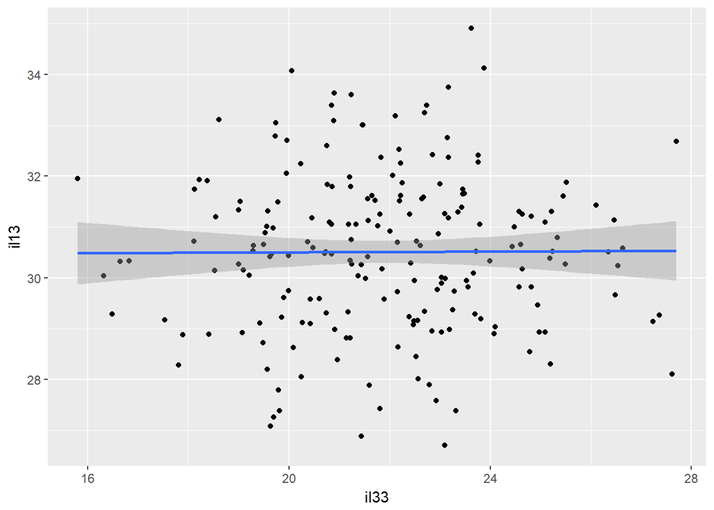

```r
myDF2 <- dataCreate(n1=200, n2=200)
lregr2 <- myReg(data=myDF2)
plot2 <-myGraph(data=lregr2)
plot2
```

```r
sampleinc<- print(summary(lregr2)$coefficients)
```

```
##                 Estimate Std. Error     t value     Pr(>|t|)
## (Intercept) 30.426721726 1.04783539 29.03769231 2.709182e-73
## il33         0.003874771 0.04753945  0.08150643 9.351215e-01
```

Adjusting the number of samples with these current means does little to alter the p value for the slope of the best fit line.

Now let us decrease the mean of IL-33:

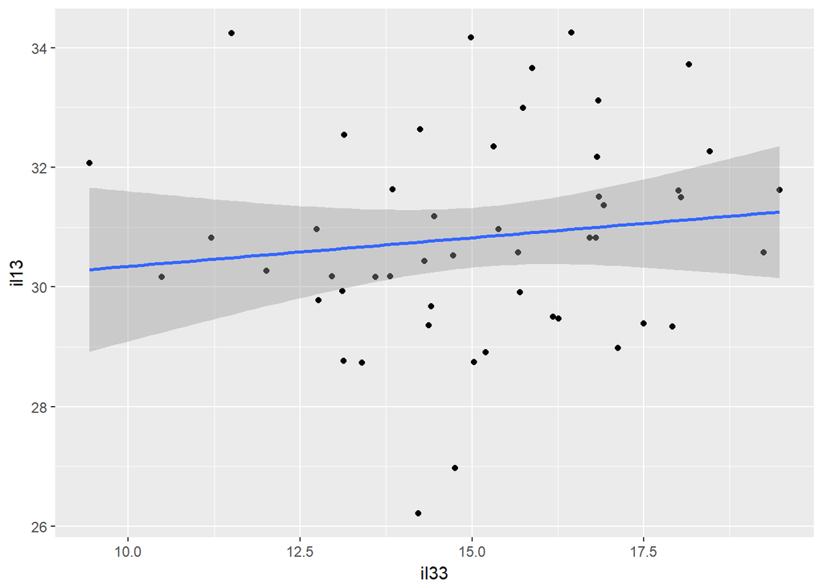

```r
myDF2 <- dataCreate(mean2=15.5)
lregr2 <- myReg(data=myDF2)
plot2 <-myGraph(data=lregr2)
plot2
```

```r
il33dec <-print(summary(lregr2)$coefficients)
```

```
##                Estimate Std. Error    t value     Pr(>|t|)
## (Intercept) 29.38784062  1.7114262 17.1715497 3.956638e-22
## il33         0.09580053  0.1120833  0.8547261 3.969489e-01
```

Now let us increase the value of IL-33

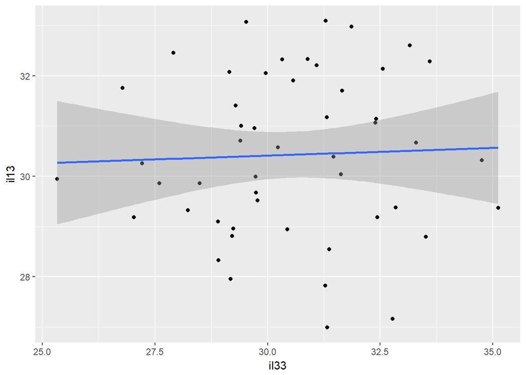

```r
myDF2 <- dataCreate(mean2=30.3)
lregr2 <- myReg(data=myDF2)
plot2 <-myGraph(data=lregr2)
plot2
```

```r
il33inc<- print(summary(lregr2)$coefficients)
```

```
##                Estimate Std. Error   t value     Pr(>|t|)
## (Intercept) 29.50342270  3.3525142 8.8003871 1.397371e-11
## il33         0.03031255  0.1096405 0.2764721 7.833725e-01
```

Now let us adjust the standard deviation for IL-33:

First decrease:

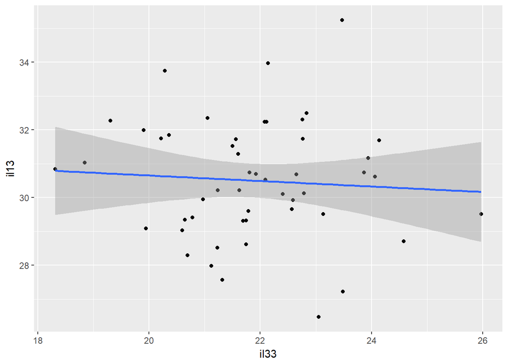

```r
myDF2 <- dataCreate(sd2=1.5)
lregr2 <- myReg(data=myDF2)
plot2 <-myGraph(data=lregr2)
plot2
```

```r
sd2dec<-print(summary(lregr2)$coefficients)
```

```
##                Estimate Std. Error    t value     Pr(>|t|)
## (Intercept) 32.28040442  3.6947651  8.7367947 1.735898e-11
## il33        -0.08128236  0.1685955 -0.4821146 6.319157e-01
```

Then increase:

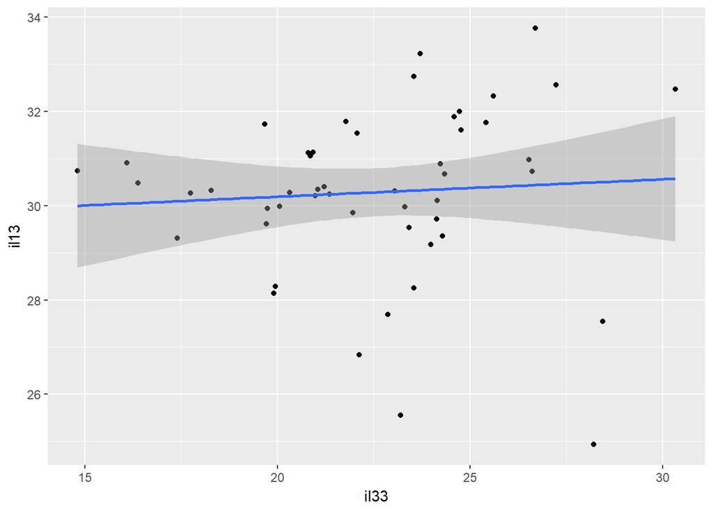

```r
myDF2 <- dataCreate(sd2=3)
lregr2 <- myReg(data=myDF2)
plot2 <-myGraph(data=lregr2)
plot2
```

```r
sd2inc<- print(summary(lregr2)$coefficients)
```

```
##                Estimate Std. Error   t value     Pr(>|t|)
## (Intercept) 29.45357742  1.7783836 16.561993 1.754374e-21
## il33         0.03697103  0.0781516  0.473068 6.383089e-01
```

```r
orimod[2,4]
```

```
## [1] 0.1171593
```

```r
sampleinc[2,4]
```

```
## [1] 0.9351215
```

```r
il33inc[2,4]
```

```
## [1] 0.7833725
```

```r
il33dec[2,4]
```

```
## [1] 0.3969489
```

```r
sd2inc[2,4]
```

```
## [1] 0.6383089
```

```r
sd2dec[2,4]
```

```
## [1] 0.6319157
```

Let us try the same process now for IL 13 Increase il13:

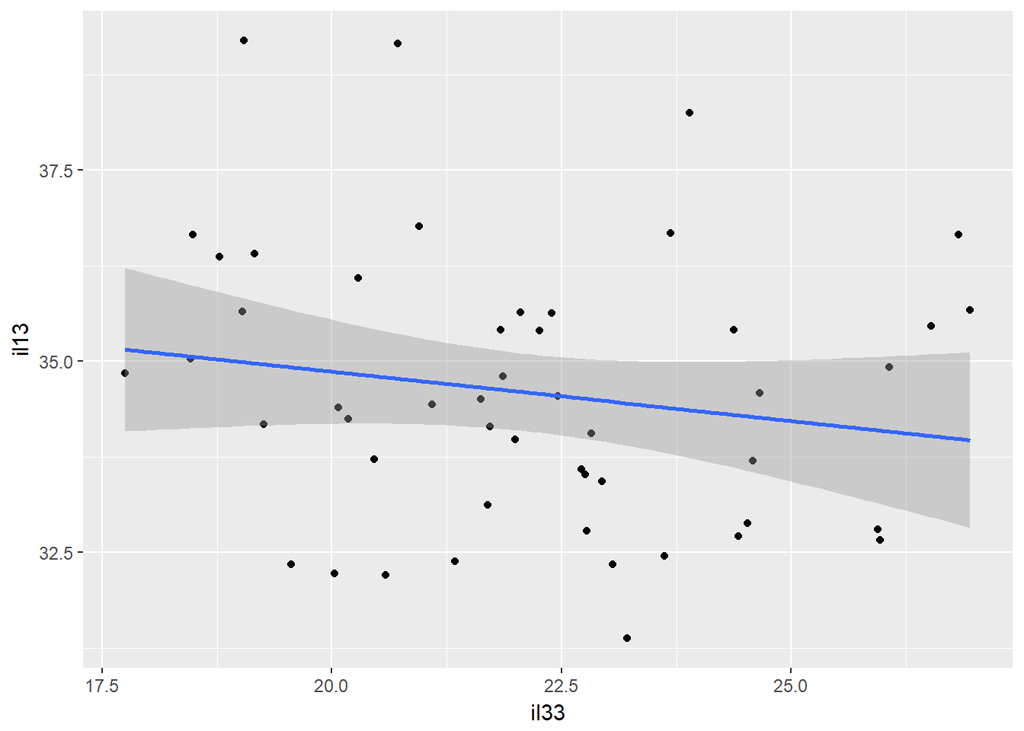

```r
myDF2 <- dataCreate(mean1=35)
lregr2 <- myReg(data=myDF2)
plot2 <-myGraph(data=lregr2)
plot2
```

```r
sd2inc<- print(summary(lregr2)$coefficients)
```

```
##               Estimate Std. Error   t value     Pr(>|t|)
## (Intercept) 37.4292857   2.371917 15.780184 1.255486e-20
## il33        -0.1282727   0.106489 -1.204563 2.342780e-01
```

Lower il13:

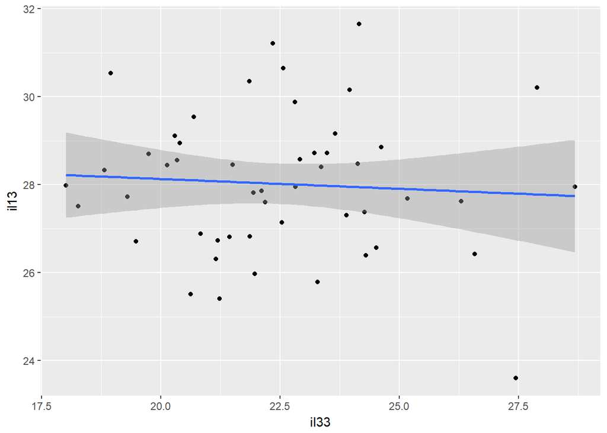

```r
myDF2 <- dataCreate(mean1=28)
lregr2 <- myReg(data=myDF2)
plot2 <-myGraph(data=lregr2)
plot2
```

```r
sd2inc<- print(summary(lregr2)$coefficients)
```

```
##               Estimate Std. Error    t value     Pr(>|t|)
## (Intercept) 29.0267353 2.15567215 13.4652829 6.415778e-18
## il33        -0.0446334 0.09540377 -0.4678368 6.420186e-01
```

increase standard deviation for il13:

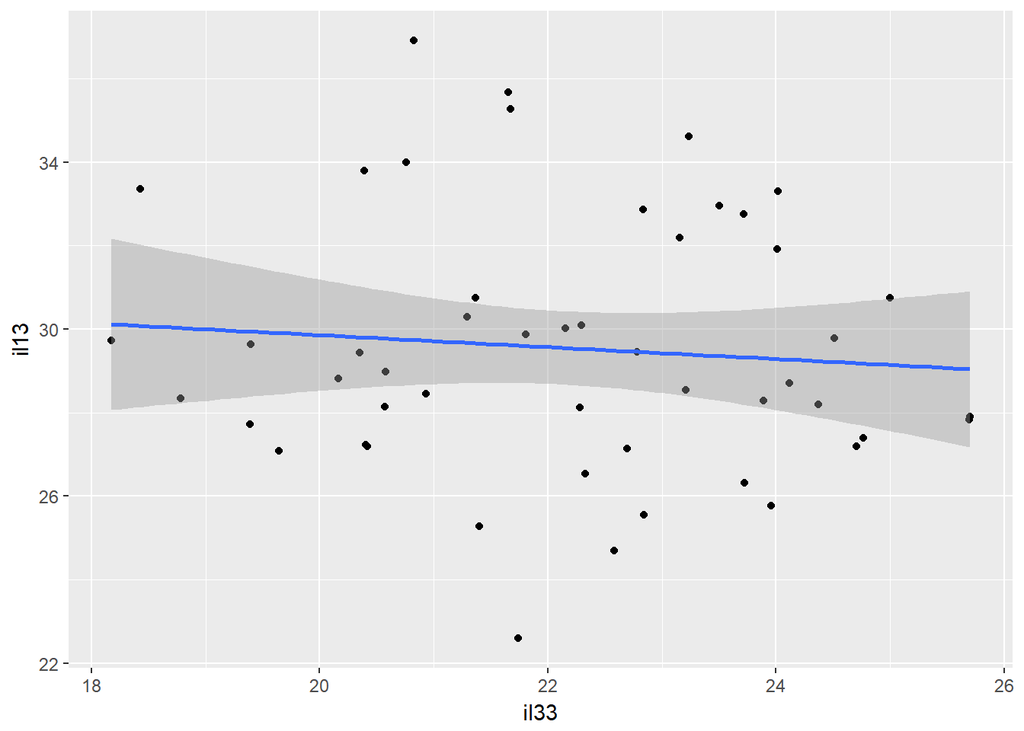

```r
myDF2 <- dataCreate(sd1=3)
lregr2 <- myReg(data=myDF2)
plot2 <-myGraph(data=lregr2)
plot2
```

```r
sd2inc<- print(summary(lregr2)$coefficients)
```

```
##               Estimate Std. Error    t value     Pr(>|t|)
## (Intercept) 32.7106390  5.1467023  6.3556501 7.160235e-08
## il33        -0.1425693  0.2313676 -0.6162026 5.406722e-01
```

decrease the standard deviation for il13:

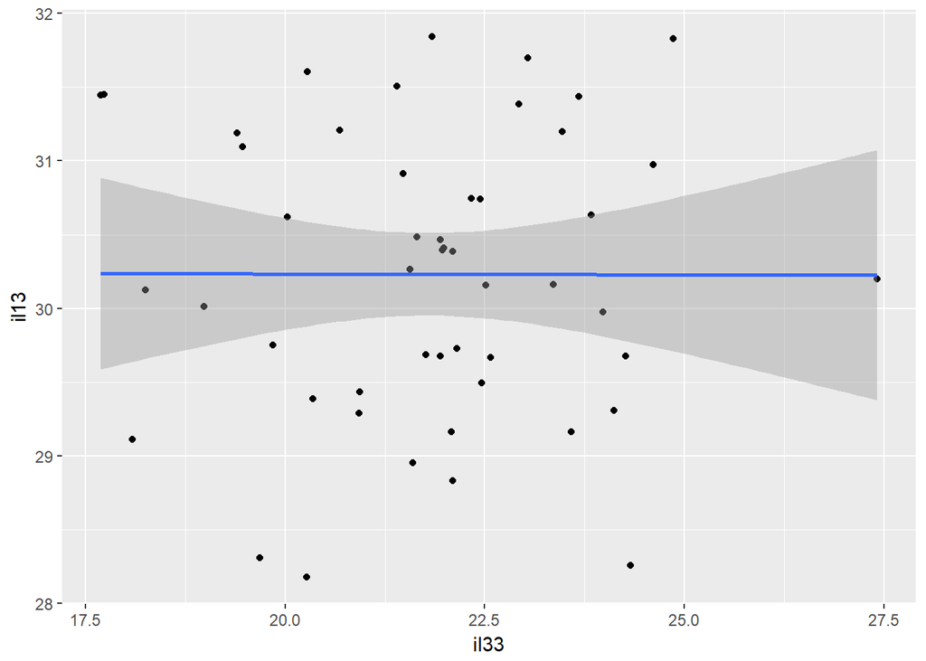

```r
myDF2 <- dataCreate(sd1=1)
lregr2 <- myReg(data=myDF2)
plot2 <-myGraph(data=lregr2)
plot2
```

```r
sd2inc<- print(summary(lregr2)$coefficients)
```

```
##                 Estimate Std. Error    t value     Pr(>|t|)
## (Intercept) 30.255721696 1.54919939 19.5299080 1.755461e-24
## il33        -0.001096947 0.07078129 -0.0154977 9.876994e-01
```

All of these alterations of parameters do nothing to produce significant results, which would indicate that IL13 and IL33 are not correlated. This is known to be false from the literature.

This spurred me to try something new: what happens if I make the standard deviations .1 for both?

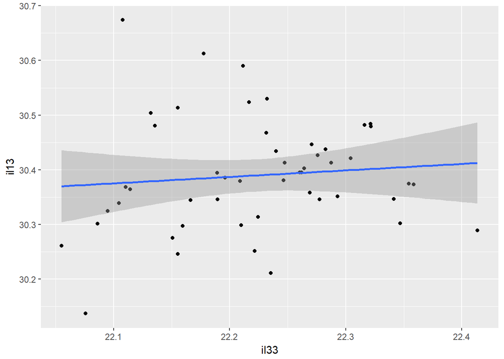

```r
myDF3 <- dataCreate(sd1=.1, sd2=.1)
lregr3 <- myReg(data=myDF3)
plot3 <-myGraph(data=lregr3)
plot3
```

```r
rel3<- print(summary(lregr3)$coefficients)
```

```
##               Estimate Std. Error   t value     Pr(>|t|)
## (Intercept) 27.7536338  3.9169508 7.0855201 5.437796e-09
## il33         0.1186235  0.1762629 0.6729917 5.041800e-01
```

After all of this work I have come to the conclusion that due to the randomness present in the normal distribution model I created, I will not be able to successfully obtain a consistently significant p value.

So at this point, I decided to try something new and simulate the data in a different manner:

```r
# new simulated data model
n <- 50
il33 <- 22.2 + runif(n, min=-2.2,max=2.2)
il13 <- 1.369*il33 + runif(n,min=-1.6, max=1.6)
ID <- seq_len(n)
regData <- data.frame(ID,il33,il13)
#linear model
regModel <- lm(il13~il33, data=regData)
summary(regModel)$coefficients
```

```
##              Estimate Std. Error    t value     Pr(>|t|)
## (Intercept) 0.8786971  2.4992894  0.3515788 7.266929e-01
## il33        1.3275241  0.1125002 11.8001953 8.558402e-16
```

```r
z <- summary(regModel)
z$coefficients
```

```
##              Estimate Std. Error    t value     Pr(>|t|)
## (Intercept) 0.8786971  2.4992894  0.3515788 7.266929e-01
## il33        1.3275241  0.1125002 11.8001953 8.558402e-16
```

```r
mySlope <- z$coefficients[2,1]
pvalue<-summary(regModel)$coefficients[2,4]
# this will most definitely give us a significant p value. Now to put it into a model
# now to put this into a function

dataCreate <- function(mean1=22.2, n1=50, n2=50){
  mydf <- data.frame(il33= mean1+ runif(n, min=-2.2,max=2.2), il13= 1.369*mean1+ runif(n,min=-1.6, max=1.6))
  return(mydf)
}
myDF1 <- dataCreate()

myReg <- function(data=myDF1){
  lreg<- lm(il13~il33, data=data)
  return(lreg)
}
lregr1 <- myReg()
summary(lregr1)
```

```
##
## Call:
## lm(formula = il13 ~ il33, data = data)
##
## Residuals:
##      Min       1Q   Median       3Q      Max
## -1.62654 -0.85633 -0.00266  0.96445  1.69238
##
## Coefficients:
##             Estimate Std. Error t value Pr(>|t|)
## (Intercept) 31.87890    2.53720  12.565   <2e-16 ***
## il33        -0.06615    0.11363  -0.582    0.563
## ---
## Signif. codes:  0 '***' 0.001 '**' 0.01 '*' 0.05 '.' 0.1 ' ' 1
##
## Residual standard error: 0.9912 on 48 degrees of freedom
## Multiple R-squared:  0.00701,    Adjusted R-squared:  -0.01368
## F-statistic: 0.3389 on 1 and 48 DF,  p-value: 0.5632
```

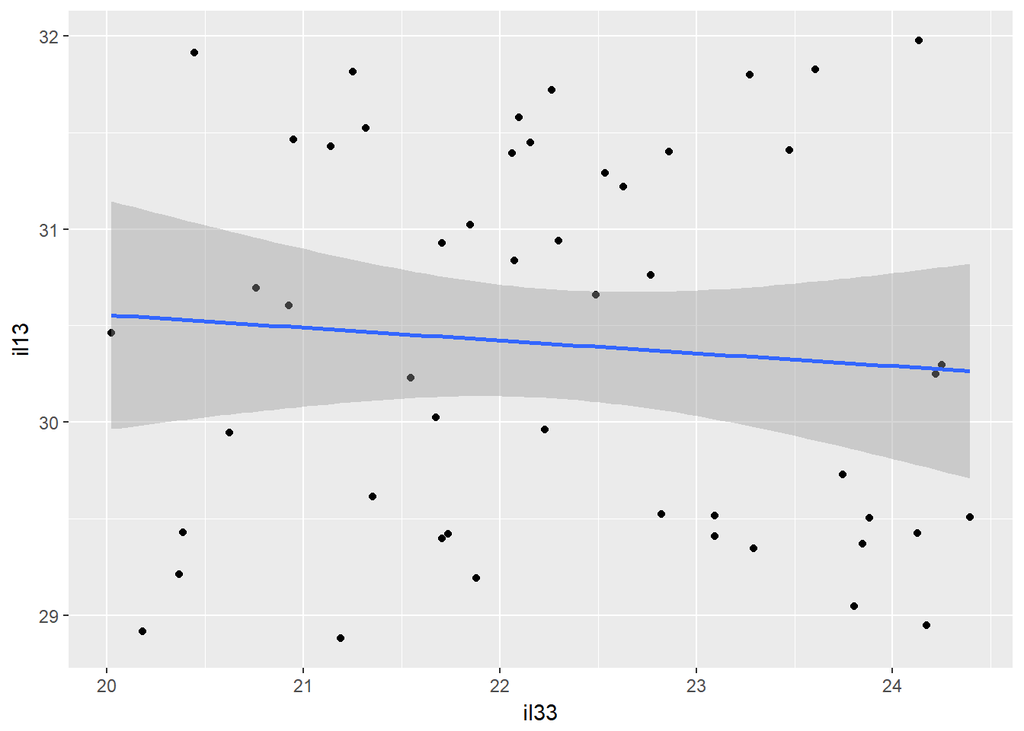

```r
myGraph <- function(data=lregr1){
  regPlot <- ggplot( data=data, mapping=aes(x=il33, y=il13))+
    geom_point()+
    stat_smooth(method=lm)

  return(regPlot)
}
plot1 <-myGraph()
plot1
```

```r
pvalue <-print(summary(lregr1)$coefficients[2,4])
```

```
## [1] 0.5632149
```

```r
summary(regModel)$coefficients
```

```
##              Estimate Std. Error    t value     Pr(>|t|)
## (Intercept) 0.8786971  2.4992894  0.3515788 7.266929e-01
## il33        1.3275241  0.1125002 11.8001953 8.558402e-16
```

```r
z <- summary(regModel)
z$coefficients
```

```
##              Estimate Std. Error    t value     Pr(>|t|)
## (Intercept) 0.8786971  2.4992894  0.3515788 7.266929e-01
## il33        1.3275241  0.1125002 11.8001953 8.558402e-16
```

```r
mySlope <- print(z$coefficients[2,1])
```

```
## [1] 1.327524
```

In short I am still figuring out how to create a model that consistently provides signficant data: this is a placeholder I will be updating this in the future. We also end up seeing, however, that the significance of the intercept is pretty much non-existent.

Part II I therefore attempted to perform the same tasks with `iris` data. The values for standard deviations, means, etc. I obtained in HW_6.

```r
dataCreate <- function(mean1=5.84, mean2=3.05, n1=150, n2=150, sd1=.8253, sd2=.4344){
  mydf <- data.frame(sepalLen=rnorm(mean=mean1, n=n1, sd=sd1), sepalWid= rnorm(mean=mean2, n=n2, sd=sd2))
  return(mydf)
}
myDF1 <- dataCreate()

head(myDF1)
```

```
##   sepalLen sepalWid
## 1 5.835545 3.334333
## 2 4.931508 2.864242
## 3 5.846693 3.201541
## 4 6.014869 2.385788
## 5 5.112041 3.078321
## 6 6.090441 2.789260
```

```r
# melt(myDF) places it in a format that can be used to perform an anova

myReg <- function(data=myDF1){
  lreg<- lm(sepalLen~sepalWid, data=data)
  return(lreg)

}
lregr1 <- myReg()
summary(lregr1)
```

```
##
## Call:
## lm(formula = sepalLen ~ sepalWid, data = data)
##
## Residuals:
##      Min       1Q   Median       3Q      Max
## -2.27890 -0.58461  0.05239  0.49248  1.80995
##
## Coefficients:
##             Estimate Std. Error t value Pr(>|t|)
## (Intercept)   6.4120     0.4723  13.575   <2e-16 ***
## sepalWid     -0.1993     0.1566  -1.273    0.205
## ---
## Signif. codes:  0 '***' 0.001 '**' 0.01 '*' 0.05 '.' 0.1 ' ' 1
##
## Residual standard error: 0.8101 on 148 degrees of freedom
## Multiple R-squared:  0.01083,    Adjusted R-squared:  0.004142
## F-statistic:  1.62 on 1 and 148 DF,  p-value: 0.2051
```

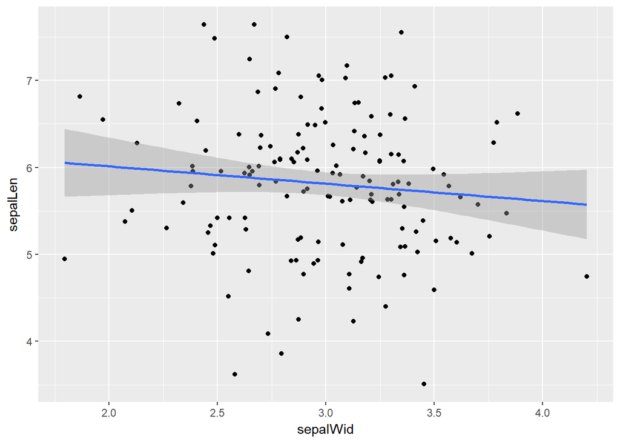

```r
myGraph <- function(data=lregr1){
  regPlot <- ggplot( data=data, mapping=aes(x=sepalWid, y=sepalLen))+
    geom_point()+
    stat_smooth(method=lm)

  return(regPlot)
}
plot1 <-myGraph()
plot1
```

```r
results1 <-print(summary(lregr1)$coefficients)
```

```
##               Estimate Std. Error   t value     Pr(>|t|)
## (Intercept)  6.4120386  0.4723278 13.575399 8.886602e-28
## sepalWid    -0.1992699  0.1565737 -1.272691 2.051235e-01
```

```r
pvalue <-print(summary(lregr1)$coefficients[2,4])
```

```
## [1] 0.2051235
```

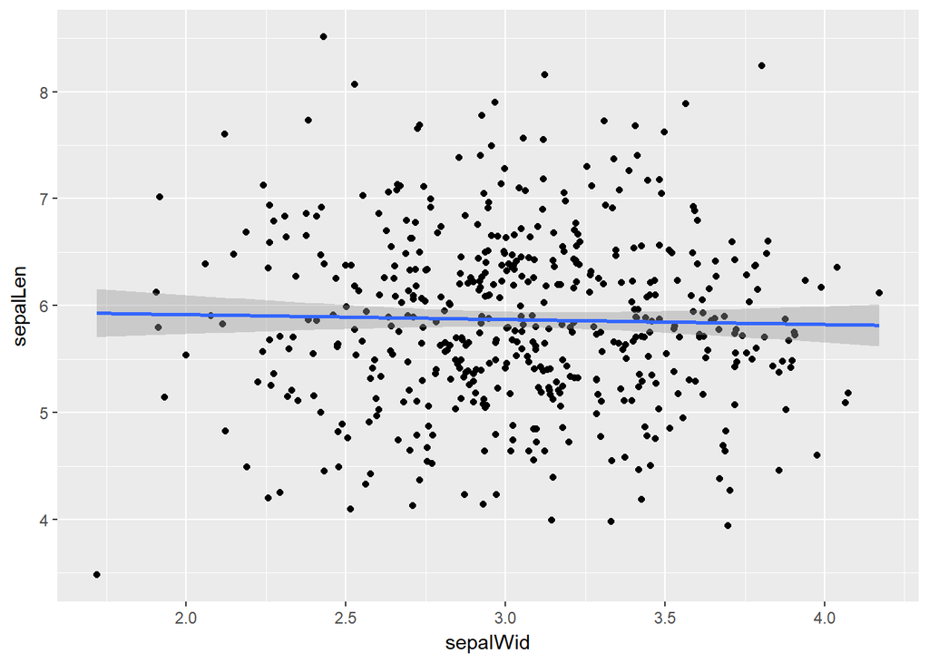

```r
#increasing N
myDF2 <- dataCreate(n1=500, n2=500)
lregr2 <- myReg(data=myDF2)
plot2 <-myGraph(data=lregr2)
plot2
```

```r
results2 <- print(summary(lregr2)$coefficients)
```

```
##               Estimate Std. Error    t value     Pr(>|t|)
## (Intercept)  6.0085606  0.2510570 23.9330546 7.976868e-85
## sepalWid    -0.0459532  0.0815502 -0.5634959 5.733509e-01
```

```r
results1[2,4]
```

```
## [1] 0.2051235
```

```r
results2[2,4]
```

```
## [1] 0.5733509
```

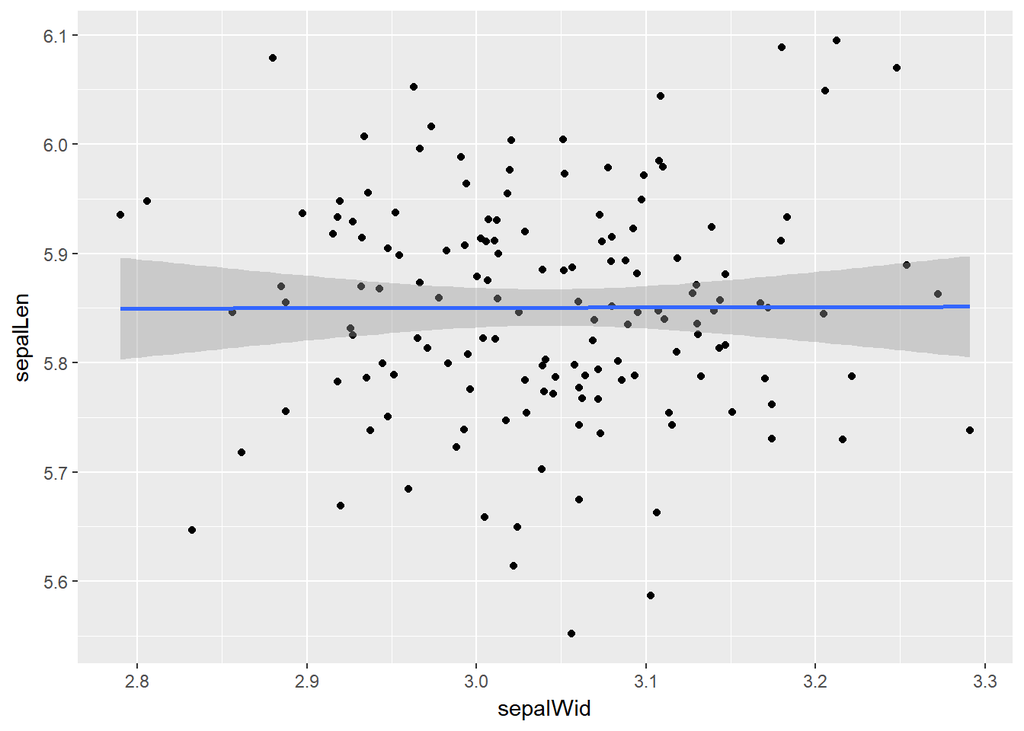

```r
# decreasing sd
myDF3 <- dataCreate(sd1=.1, sd2=.1)
lregr3 <- myReg(data=myDF3)
plot3 <-myGraph(data=lregr3)
plot3
```

```r
rel3<- print(summary(lregr3)$coefficients)
```

```
##                Estimate Std. Error     t value     Pr(>|t|)
## (Intercept) 5.840313593 0.26725512 21.85295305 3.545693e-48
## sepalWid    0.003353163 0.08780872  0.03818712 9.695899e-01
```

```r
rel3[2,4]
```

```
## [1] 0.9695899
```

```r
#increasing sd
myDF4 <- dataCreate(sd1=3)
lregr4 <- myReg(data=myDF4)
#plot2 <-myGraph(data=lregr2)
#plot2
sd1inc<- print(summary(lregr4)$coefficients)
```

```
##              Estimate Std. Error  t value   Pr(>|t|)
## (Intercept) 4.2228444  1.7260270 2.446569 0.01559387
## sepalWid    0.5679532  0.5562008 1.021130 0.30885917
```

```r
sd1inc[2,4]
```

```
## [1] 0.3088592
```

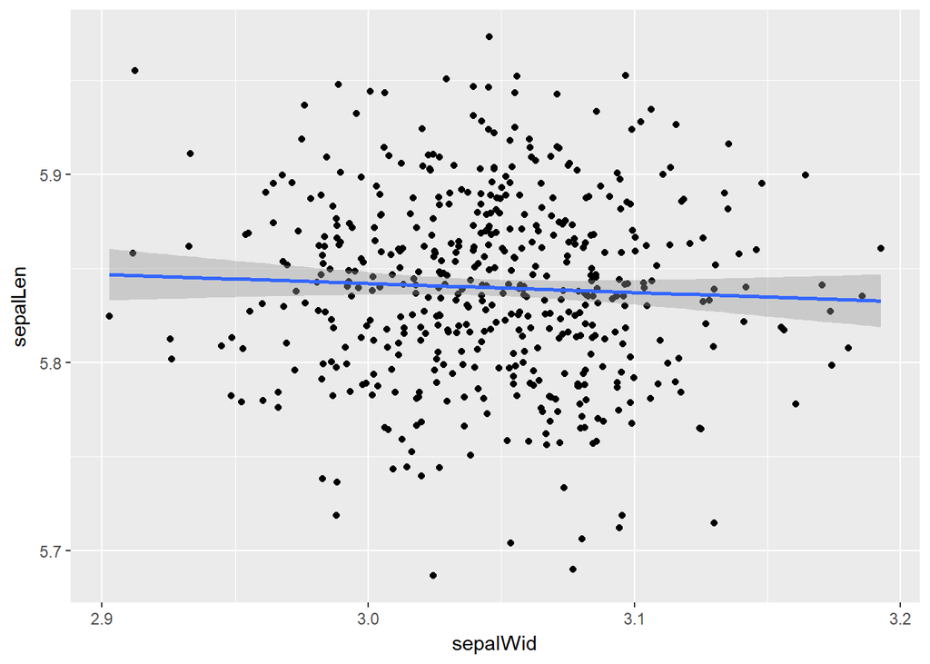

```r
#increasing mean and decreasing sd
myDF5 <- dataCreate(sd1=.05, sd2=.05, n1=500, n2=500)
lregr5 <- myReg(data=myDF5)
plot5 <-myGraph(data=lregr5)
plot5
```

```r
rel5<- print(summary(lregr5)$coefficients)
```

```
##                Estimate Std. Error   t value      Pr(>|t|)
## (Intercept)  5.98568295 0.14063565 42.561632 5.012915e-168
## sepalWid    -0.04791312 0.04615663 -1.038055  2.997482e-01
```

```r
rel5[2,4]
```

```
## [1] 0.2997482
```

```r
z <- lm(Sepal.Length~Sepal.Width, data=iris)
z
```

```
##
## Call:
## lm(formula = Sepal.Length ~ Sepal.Width, data = iris)
##
## Coefficients:
## (Intercept)  Sepal.Width
##      6.5262      -0.2234
```

```r
summary(z)
```

```
##
## Call:
## lm(formula = Sepal.Length ~ Sepal.Width, data = iris)
##
## Residuals:
##     Min      1Q  Median      3Q     Max
## -1.5561 -0.6333 -0.1120  0.5579  2.2226
##
## Coefficients:
##             Estimate Std. Error t value Pr(>|t|)
## (Intercept)   6.5262     0.4789   13.63   <2e-16 ***
## Sepal.Width  -0.2234     0.1551   -1.44    0.152
## ---
## Signif. codes:  0 '***' 0.001 '**' 0.01 '*' 0.05 '.' 0.1 ' ' 1
##
## Residual standard error: 0.8251 on 148 degrees of freedom
## Multiple R-squared:  0.01382,    Adjusted R-squared:  0.007159
## F-statistic: 2.074 on 1 and 148 DF,  p-value: 0.1519
```

This leads me to wonder if the reason why I am not able to consistently obtain a significant p value may in fact be due to the fact that I am using rnorm for the variables and I could do rnorm() when simulating one observation but relate the other observation to the first via an equation(this, however, already indicates that there is a relationship between the two observations). Also picking different observations within `iris` would have helped as well.